# Dataframes / Histograms / Sampling

Sulalitha Bowala

## Dataframes

### Importing Data

Importing data from external files like Excel and CSV into R and RStudio is important for several reasons:

1. **Data Accessibility:** Many datasets are stored in external files in formats like Excel spreadsheets or CSV files. Importing data allows you to access and analyze this information using R’s powerful data manipulation and analysis tools.
2. **Data Integrity:** Importing data directly from files helps maintain data integrity. It ensures that the data you are working with is the same as the original source, reducing the risk of data entry errors or data loss during manual copying.
3. **Efficiency:** Manual data entry is time-consuming and error-prone. Importing data from files is more efficient, especially when dealing with large datasets. It saves you time and reduces the chance of introducing errors.
4. **Data Transformation:** R provides a wide range of functions and packages for data cleaning and transformation. Importing data into R allows you to take advantage of these capabilities to prepare and shape your data for analysis.
5. **Reproducibility:** Importing data from files ensures that your analysis is reproducible. Others can replicate your work exactly because they have access to the same dataset.
6. **Automation:** Data import can be automated as part of a data analysis pipeline. You can write scripts that automatically fetch and import updated data, making your analysis more dynamic.
7. **Compatibility:** R can work with various data file formats, including CSV, Excel, SQL databases, and more. This flexibility makes it possible to integrate data from different sources into a unified analysis.
8. **Data Exploration:** Importing data allows you to perform initial data exploration tasks, such as summary statistics, data visualization, and understanding the structure of the dataset, all within RStudio.
9. **Integration with Analysis:** Once data is imported, you can seamlessly integrate it with your data analysis workflow, including statistical analysis, modeling, and visualization, all within the R environment.
10. **Collaboration:** Importing data into RStudio enables collaborative data analysis. Team members can work on the same dataset, share scripts, and collaborate on data-driven projects.

In summary, importing data from files is a fundamental step in data analysis using R and RStudio. It ensures data accessibility, integrity, efficiency, and reproducibility, allowing you to take full advantage of R’s capabilities for data analysis and modeling.

If you have a csv file that contains data, you can save the file in your working directory, and use the read.csv() function. This will save the information in the csv file as a dataframe.

When importing a .csv file into R, there are a few different options. In this class, we will ask you to always import data by following the steps below:

**Step 1**: Open the “file” dropdown in the top-left of your screen, and select “Import Dataset” > “From Text (Base)”. This will open up a window where you will locate the file on your computer.

**Step 2**: Navigate to the .csv file on your computer, and select it.

**Step 3**: This will open up the window below, where you will have a few options:

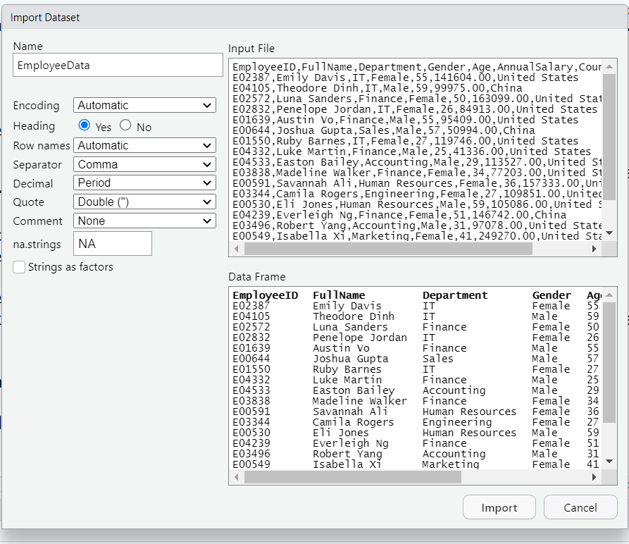

You should leave all of the settings at their defaults, except for two things: the “**Name**”, and the “**Heading**”.

**Name**: set this to whatever you want your dataset to be named. You can call it whatever you want, but you should keep it short, and do NOT include any spaces.

**Heading**: this will identify whether the first row of your dataset is a “header” row, i.e., whether the first row of your dataset is column names. Usually in this class, that will be the case, so this should generally be set to “Yes”.

**Step 4**: Click “Import”. This will run two lines of code in your console:

- Syntax: **FileName <- read.csv(file location, other optional settings…)**

The “read.csv” function will import your dataset with the settings chosen. Note that it is in fact this line of code that is importing the dataset. I.e., you could technically just run this line of code - the import process simply generates the file location, as well as assigning any desired settings, runs the function, and saves the imported file with your desired name.

- Syntax: **View(FileName)**

This function will open your dataset in a separate tab. You cannot modify your file here, but you may view the imported file.

You should always save the first line generated code from this process in your script. That way, in the future, you may simply run this one line of code instead of repeating the entire process to import your dataset.

**If you are making an RMarkdown file, this line of code must appear in a code chunk for your document to knit properly.**

For example, if I had the information on the set of employees of a company saved in a file called Employee.csv, I would save the file to my working directory and follow the 4 steps of importing data.

```r
Employee <- read.csv("Employee.csv")
```

**Note**: This line of code will look different for you, as it is pointing to the location of the dataset on your machine. However, if both the Rmd file and the CSV files are saved in the same folder, we can directly use a relative path like “data.csv” to import the dataset without specifying the full file path.

When you import a dataset into R, it will take the form of what is called a dataframe. A dataframe is nothing more than a collection of vectors, where each vector is a single column.

### View Dataframes

Note in the “Environment” window, R creates a subsection called “Data” and shows your dataframe name “Employee”. It also provides information about your dataframe, such as the number of observations (number of rows) and number of variables (number of columns). If you click on the dataframe name, it will pop up as a new window next to your R Markdown file.

We can simply type the dataframe name in the console to print it out. However, this is recommended when we have small dataset. Many files will be too large to view in this way.

When we have large datasets, we can use the **head()**, **tail()**, and **str()** functions.

The head function will print the first 6 rows of your dataframe by default. This is useful for checking how exactly the values in your dataset look.

```r
head(Employee)
```

```
##   EmployeeID        FullName Department Gender Age AnnualSalary       Country
## 1     E02387     Emily Davis         IT Female  55       141604 United States
## 2     E04105   Theodore Dinh         IT   Male  59        99975         China
## 3     E02572    Luna Sanders    Finance Female  50       163099 United States
## 4     E02832 Penelope Jordan         IT Female  26        84913 United States
## 5     E01639       Austin Vo    Finance   Male  55        95409 United States
## 6     E00644    Joshua Gupta      Sales   Male  57        50994         China
```

**Note**:

In R and RStudio, functions are essential for performing various operations. For an example “head()” function display first 6 observations in your dataframe. We can add more details to functions in R/RStudio through what are called arguments. For an example, if we need to display first 10 observations instead first 6 observations, we can add that as an argument.

The additional arguments of a function must stay within the brackets of the function, must be separated by commas, and must be referenced by name. Different functions accept different arguments as they are designed to perform different tasks. We can view more details about functions by typing “**?FunctionName**” in the Console, and information appears in the Help tab in the “Plot/Help Panel/File Explorer/ Packages” window.

Example:

```r
?head
```

```
## starting httpd help server ... done
```

```r
head(Employee, n = 10)
```

```
##    EmployeeID        FullName Department Gender Age AnnualSalary       Country
## 1      E02387     Emily Davis         IT Female  55       141604 United States
## 2      E04105   Theodore Dinh         IT   Male  59        99975         China
## 3      E02572    Luna Sanders    Finance Female  50       163099 United States
## 4      E02832 Penelope Jordan         IT Female  26        84913 United States
## 5      E01639       Austin Vo    Finance   Male  55        95409 United States
## 6      E00644    Joshua Gupta      Sales   Male  57        50994         China
## 7      E01550     Ruby Barnes         IT Female  27       119746 United States
## 8      E04332     Luke Martin    Finance   Male  25        41336 United States
## 9      E04533   Easton Bailey Accounting   Male  29       113527 United States
## 10     E03838 Madeline Walker    Finance Female  34        77203 United States
```

We can view last 6 observations in your working dataframe by using the “**tail()**” function.

```r
tail(Employee)
```

```
##    EmployeeID       FullName      Department Gender Age AnnualSalary
## 25     E02071      Mateo Her           Sales   Male  44       207172
## 26     E02206 Jose Henderson Human Resources   Male  41       152239
## 27     E04545  Abigail Mejia     Engineering Female  56        98581
## 28     E00154     Wyatt Chin     Engineering   Male  43       246231
## 29     E03343      Carson Lu     Engineering   Male  64        99354
## 30     E00304     Dylan Choi              IT   Male  63       231141
##          Country
## 25         China
## 26 United States
## 27        Brazil
## 28 United States
## 29         China
## 30         China
```

The **str()** function will show the structure of your dataframe. It will show all of the variables, along with their data type, as well as some example values.

```r
str(Employee)
```

```
## 'data.frame':    30 obs. of  7 variables:
##  $ EmployeeID  : chr  "E02387" "E04105" "E02572" "E02832" ...
##  $ FullName    : chr  "Emily Davis" "Theodore Dinh" "Luna Sanders" "Penelope Jordan" ...
##  $ Department  : chr  "IT" "IT" "Finance" "IT" ...
##  $ Gender      : chr  "Female" "Male" "Female" "Female" ...
##  $ Age         : int  55 59 50 26 55 57 27 25 29 34 ...
##  $ AnnualSalary: num  141604 99975 163099 84913 95409 ...
##  $ Country     : chr  "United States" "China" "United States" "United States" ...
```

### The $ operator

The $ operator in R and RStudio is used to access and extract specific components or variables from data structures, typically from data frames and lists. It allows you to directly reference and work with specific columns or elements within these data structures.

For example, Let’s assume we want to access just the “Age” of each employee.

- **Syntax**: DataframeName$ColumnName

```r
Employee$Age
```

```
##  [1] 55 59 50 26 55 57 27 25 29 34 36 27 59 51 31 41 65 64 64 45 56 36 59 37 44
## [26] 41 56 43 64 63
```

We can also run functions on a selected variable/column:

```r
mean(Employee$Age)
```

```
## [1] 46.63333
```

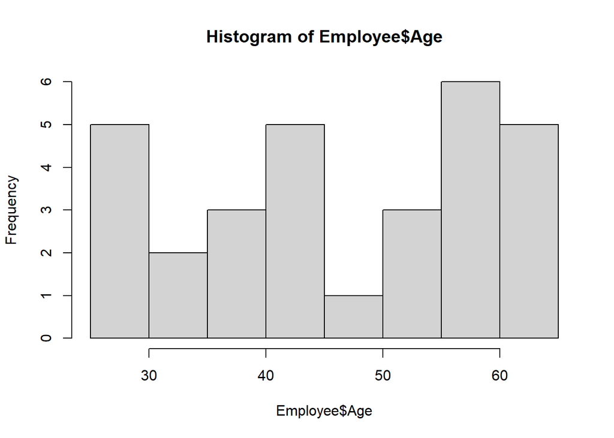

```r
hist(Employee$Age)
```

**Note**: If needed, we can also save the values in a column for future use. This avoids using the “$ operator” again and again.

```r
Employee_Age <- Employee$Age

mean(Employee_Age)
```

```
## [1] 46.63333
```

- While you have flexibility in choosing variable names, they cannot contain spaces, begin with a number, or include specific reserved symbols.

### Histograms

In R/RStudio, you can create histograms to visualize the distribution of a numeric variable. Histograms display the frequency or density of values within predefined bins or intervals.

Let EmployeeComplete.csv contain information on all the employees in a company. The company salary department conducting a study on employees’ annual salaries, and they want to produce a histogram based on annual salary details.

```r
EmployeeComplete <- read.csv("EmployeeComplete.csv")
```

First, the team working on the study produce a basic histogram using the function “**hist()**”.

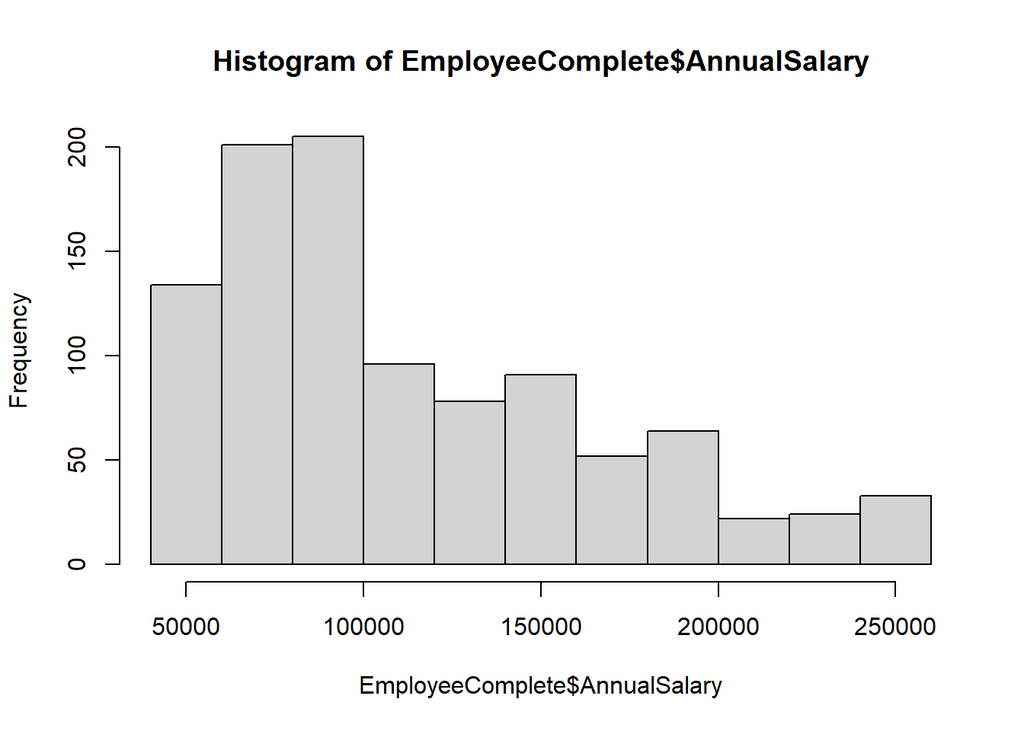

```r
hist(EmployeeComplete$AnnualSalary)
```

Even though this provides some information about the distribution of annual salaries, the department head in the salary department wants to have a different title, axis labels, and see more details, such as the mean and median of annual salaries on the graph.

We know we can add more details to a function by adding arguments (recall “head()” function). For the **hist()** function, the most common arguments are as follows:

**Syntax**: hist(x, breaks = …, main = …, xlab = …, ylab = …, and col = …)

- **x**: The vector x is the dataset we provide.
- **breaks**: The number of bins or intervals to divide the data into. Note that R will often not give you the exact number of bins that you ask for. Instead, it will give you the nearest number of bins that it determines to be “pretty”.
- **main**: The main title for the plot. Note that, since you will be supplying a set of characters as your argument, this will need to be wrapped in quotation marks.
- **xlab**: The label for the X-axis.
- **ylab**: The label for the Y-axis.
- **col**: The color of the bars.
- **border**: The color of the bar borders.

**Note**: More details with some examples can be found using the “?hist” in R/RStudio.

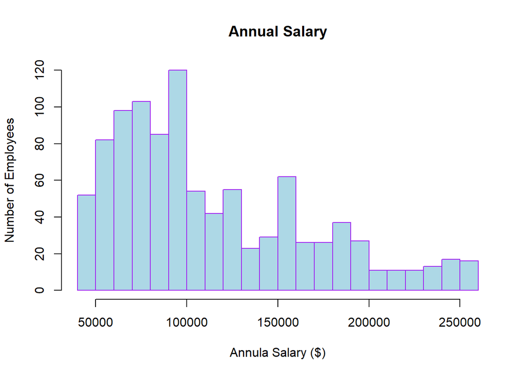

```r
hist(EmployeeComplete$AnnualSalary, breaks = 30, main = "Annual Salary", xlab = "Annula Salary ($)", ylab = "Number of Employees", col = "lightblue", border = "purple")
```

**Note**: If your code runs off the page (you can tell where this is going to happen by looking for the thin grey vertical line spanning the screen in R Markdown), make sure you break the line by pressing Enter / Return after a comma. (You can clearly see this when you knit and create the PDF)

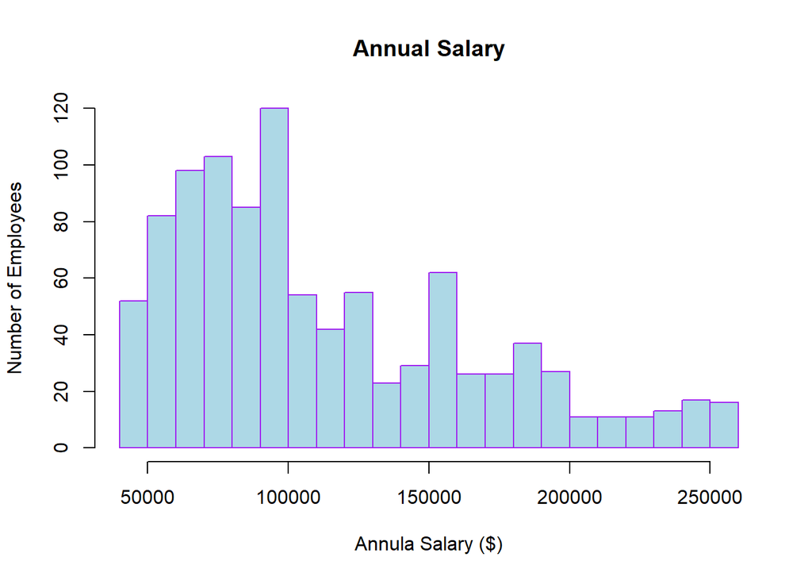

```r
hist(EmployeeComplete$AnnualSalary, breaks = 30, main = "Annual Salary",
     xlab = "Annula Salary ($)", ylab = "Number of Employees",
     col = "lightblue", border = "purple")
```

As per the request of salary deparment head, We want to add mean and median into our annual salary histogram.

In R and RStudio, the **abline()** function is used to add lines to a plot, including horizontal, vertical, and diagonal lines. You can use it to enhance your visualizations by adding reference lines and other lines of interest to your plots.

**Syntax**: abline(a = NULL, b = NULL, h = NULL, v = NULL, reg = NULL, coef = NULL, untf = FALSE, …)

Here are some common arguments you can use with abline():

- **h**: The y-coordinate for horizontal lines.
- **v**: The x-coordinate for vertical lines.
- **a and b**: The intercept and slope for diagonal lines. (Discuss in Unit 7)
- **col**: The color of the line.
- **lty**: The line type (lty = 1: Solid line (default), lty = 2: Dashed line, lty = 3: Dotted line, lty = 4: Dot-dash line, lty = 5: Long-dash line, lty = 6: Two dash-dot line, lty = 7: Two-dot line, lty = 8: Dash-dot-dot line).
- **lwd**: The line width.

```r
?abline
```

In R, you can calculate the median of a numeric vector or a dataset using the **median()** function.

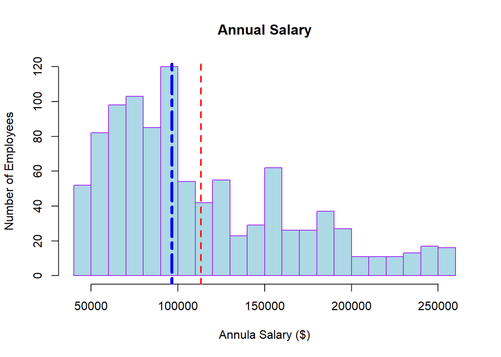

```r
hist(EmployeeComplete$AnnualSalary, breaks = 30, main = "Annual Salary",
     xlab = "Annula Salary ($)", ylab = "Number of Employees",
     col = "lightblue", border = "purple")

# Add mean and median

abline(v = mean(EmployeeComplete$AnnualSalary), col = "red", lty = 2, lwd = 2)

abline(v = median(EmployeeComplete$AnnualSalary), col = "blue",
       lty = 6, lwd = 4)
```

To add a label to an **abline()** in R, you can use the **text()** function to place text near the line on your plot. The **text()** function takes the x and y coordinates where you want to place the text and the text itself.

**Syntax**: text(x, y = NULL, labels = seq_along(x$x), adj = NULL, pos = NULL, offset = 0.5, vfont = NULL, cex = 1, col = NULL, font = NULL, …)

Here are some common arguments you can use with text():

- **x and y**: The coordinates where you want to place the text.
- **labels**: The text or labels you want to add.
- **col**: The color of the text.
- **cex**: The scaling factor for the text size. A value greater than 1 makes the text larger.
- **srt**: Rotate the text at a specified angle.

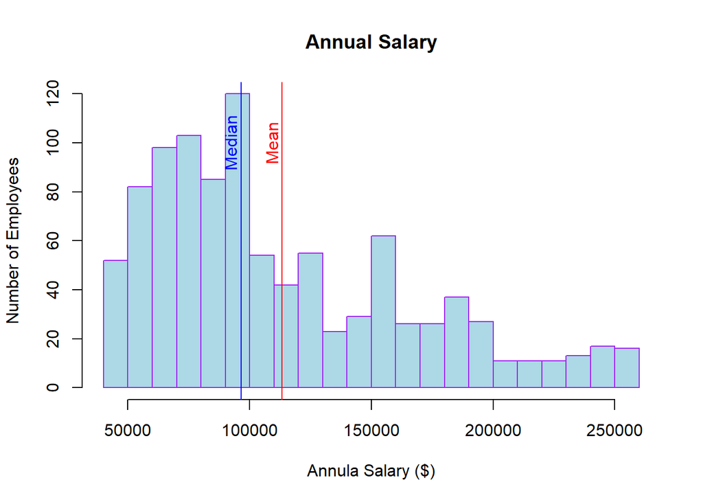

```r
hist(EmployeeComplete$AnnualSalary, breaks = 30, main = "Annual Salary",
     xlab = "Annula Salary ($)", ylab = "Number of Employees",
     col = "lightblue", border = "purple")

# Add mean and median

abline(v = mean(EmployeeComplete$AnnualSalary), col = "red")

abline(v = median(EmployeeComplete$AnnualSalary), col = "blue")

# Add labels to mean and median

text(x = 109000, y = 100, labels = "Mean", col="red", srt=90)

text(x = 92000, y = 100, labels = "Median", col="blue", srt=90)
```

## Sampling

In R, the **sample()** function is used to generate random samples from a specified set of values.

```r
?sample
```

**Syntax**: sample(x, size, replace = FALSE, …)

Here are some common arguments you can use with sample():

- **x**: The vector or population from which to sample.
- **size**: The number of values to sample.
- **replace**: A logical value indicating whether sampling should be done with replacement (TRUE) or without replacement (FALSE). If replace is TRUE, the same value can be selected more than once in the sample.

Let we want to sample 100 employees’ annual salaries and calculate mean annual salary.

```r
My_Annual_Salary_Sample <- sample(EmployeeComplete$AnnualSalary, 100,
                                  replace = FALSE)

mean(My_Annual_Salary_Sample)
```

```
## [1] 116976.3
```